# Linear Algebra and Polynomials

Rajesh Majumder

March 23, 2023

**Numpy** and **Scipy** packages are used for dealing with most of the mathematical operations ilke matrix operations polynomial, numarical integration, fourier series and many more.

## A. Linear Algebra

### 1. Creating matrices and checking dimenssion

```python
import numpy as np

A= np.array([[1,2,3],
            [4,5,6]])

B= np.array([[1,2],
             [3,4],
             [5,6]])

C= np.array([[7,8,9],
             [10,11,12]])

print("Matrix A:")
print(A)
print("Dimension:")
print(A.shape)

print("\nMatrix B:")
print(B)
print("Dimension:")
print(B.shape)

print("\nMatrix C:")
print(C)
print("Dimension:")
print(C.shape)
```

```
Matrix A:
[[1 2 3]
 [4 5 6]]
Dimension:
(2, 3)

Matrix B:
[[1 2]
 [3 4]
 [5 6]]
Dimension:
(3, 2)

Matrix C:
[[ 7  8  9]
 [10 11 12]]
Dimension:
(2, 3)
```

### 2. Transpose of a Matrix

```python
A.transpose()
```

```
array([[1, 4],
       [2, 5],
       [3, 6]])
```

### 3. Matrix Addition and Subtraction

```python
D= A+C

print(D)
```

```
[[ 8 10 12]
 [14 16 18]]
```

```python
A+B
```

```
---------------------------------------------------------------------------
ValueError                                Traceback (most recent call last)
~\AppData\Local\Temp\ipykernel_9560\3267467007.py in <module>
----> 1 A+B

ValueError: operands could not be broadcast together with shapes (2,3) (3,2)
```

```python
D-A
```

```
array([[ 7,  8,  9],
       [10, 11, 12]])
```

### 4. Adding each element of Matrix

$$A= \left[\begin{array}{ccc} a_{11} & a_{12} & . & . & . & a_{1p}\\ a_{21} & a_{22} & . & . & . & a_{2p}\\ . & . & . & . & . & .\\ . & . & . & . & . & .\\ . & . & . & . & . & .\\ a_{n1} & a_{n2} & . & . & . & a_{np}\\ \end{array}\right]$$

then, $$\sum_{i=0}^{n-1}{\sum_{j=0}^{p-1}{a_{(i,j)}}}$$

```python
print("Element wise Sum of A : ",sum(sum(A)) )
```

```
Element wise Sum of A :  21
```

### 5. Element wise Matrix Multiplication (Hadmad Product)

```python
A*C
```

```
array([[ 7, 16, 27],
       [40, 55, 72]])
```

### 6. Matrix Multiplication (Dotproduct)

$(AB)_{ij}= \sum_{k=0}^{p-1}{A_{ik}B_{kj}}$

```python
print("A*B =", A.dot(B))

# Working Alternative 1
print("\nOutput by Alternative 1")
print("A*B =", np.dot(A,B))

# Working Alternative 2
print("\nOutput by Alternative 2")
print("A*B =", np.mat(A)*np.mat(B))

# Working Alternative 2
print("\nOutput by Alternative 3")
print("A*B =",  np.matmul(A,B))
```

```
A*B = [[22 28]
 [49 64]]

Output by Alternative 1
A*B = [[22 28]
 [49 64]]

Output by Alternative 2
A*B = [[22 28]
 [49 64]]

Output by Alternative 3
A*B = [[22 28]
 [49 64]]
```

- *Note:* `np.mat()` interpret the input as a matrix.

### 7. Cross Product

```python
np.cross(A,C)
```

```
array([[-6, 12, -6],
       [-6, 12, -6]])
```

#### For calculating $X^TY$:

```python
X= np.array([[2,1],
             [3,2],
             [-2,2]])

Y= np.array([[1,1],
             [4,2],
             [-2,1]])

np.dot(np.transpose(X),Y)
```

```
array([[18,  6],
       [ 5,  7]])
```

### 8. Diagonal Matrix

```python
a= [1,2,3,4]

Diag1= np.diag(a)
print(Diag1)

np.diag()
```

[output not shown]

```python
x = np.arange(16).reshape((4,4))

print(x)
```

```
[[ 0  1  2  3]
 [ 4  5  6  7]
 [ 8  9 10 11]
 [12 13 14 15]]
```

```python
np.diag(x)
```

```
array([ 0,  5, 10, 15])
```

### 9. Upper and Lower Triangular Matrix

`np.tril()` for lower triangle

`np.triu()` for upper triangle

```python
## Creating lower triangular matrix including the diagonal
np.tril([1,2,3,4],0)
```

```
array([[1, 0, 0, 0],
       [1, 2, 0, 0],
       [1, 2, 3, 0],
       [1, 2, 3, 4]])
```

```python
x
```

```
array([[ 0,  1,  2,  3],
       [ 4,  5,  6,  7],
       [ 8,  9, 10, 11],
       [12, 13, 14, 15]])
```

```python
np.tril(x,k=-1) ## Lower triangle of x
```

```
array([[ 0,  0,  0,  0],
       [ 4,  0,  0,  0],
       [ 8,  9,  0,  0],
       [12, 13, 14,  0]])
```

```python
np.tril(x,k=1)
```

```
array([[ 0,  1,  0,  0],
       [ 4,  5,  6,  0],
       [ 8,  9, 10, 11],
       [12, 13, 14, 15]])
```

```python
np.triu(x,k=0) #upper triangular matrix including the diagonal
```

```
array([[ 0,  1,  2,  3],
       [ 0,  5,  6,  7],
       [ 0,  0, 10, 11],
       [ 0,  0,  0, 15]])
```

```python
np.triu(x,k=1) ## Upper triangle of x
```

```
array([[ 0,  1,  2,  3],
       [ 0,  0,  6,  7],
       [ 0,  0,  0, 11],
       [ 0,  0,  0,  0]])
```

```python
np.triu(x,k=-1)
```

```
array([[ 0,  1,  2,  3],
       [ 4,  5,  6,  7],
       [ 0,  9, 10, 11],
       [ 0,  0, 14, 15]])
```

### 10. Determinant of a Matrix

To doing more complecated linear algebra operations NumPy has a submodule called `linalg`.

We can import linalg globally or directly we can use it.

```python
import numpy as np
import numpy.linalg as la

xdet= la.det(x)
print(xdet)
```

```
-2.9582283945787796e-30
```

```python
M= np.array([[-1,3,0],
             [2,1,-5],
             [1,4,-2]])

print("Determinant of M: ", np.linalg.det(M))
```

```
Determinant of M:  -21.00000000000001
```

### 11. Inverse of Matrix

```python
print(la.inv(M))
```

```
[[-0.85714286 -0.28571429  0.71428571]
 [ 0.04761905 -0.0952381   0.23809524]
 [-0.33333333 -0.33333333  0.33333333]]
```

### 12. Trace of a Matrix

```python
A= np.array(np.random.randint(low=10,high=50,size=16).reshape(4,4))
print("A:")
print(A)

print("\nTrace Of A is:")
print(np.trace(A))
```

```
A:
[[10 11 19 40]
 [18 19 28 37]
 [39 27 20 30]
 [17 39 23 33]]

Trace Of A is:
82
```

### 13. Eigen values, Eigen vectors

```python
la.eig(x)
```

```
(array([ 3.24642492e+01, -2.46424920e+00,  4.52933966e-17, -1.52275132e-15]),
 array([[-0.11417645, -0.7327781 ,  0.01936986, -0.48846795],
        [-0.3300046 , -0.28974835,  0.38216644,  0.83598112],
        [-0.54583275,  0.15328139, -0.82244247, -0.20655839],
        [-0.76166089,  0.59631113,  0.42090617, -0.14095478]]))
```

```python
la.eigvals(x)
```

```
array([ 3.24642492e+01, -2.46424920e+00,  4.52933966e-17, -1.52275132e-15])
```

### 14. Rank of a Matrix

```python
la.matrix_rank(x)
```

```
2
```

### 15. Row Sum and Column Sum of Matrix

```python
print(A)

## Row sum of A:
print("\nRow Sum of A:")
print(np.sum(A,1))

## Coluumn sum of A:
print("\nColumn Sum of A:")
print(np.sum(A,0))
```

[output not shown]

### 16. Add New Column or Row

`np.append()` is used for adding a new row.

`np.insert()` is used for adding a new column.

```python
m= np.array([["Mon",18,20,22,17],
          ["Tue",11,13,15,12],
          ["Wed",15,21,20,29],
          ["Thu",11,10,22,21],
          ["Fir",12,14,20,18]])

print("Original Matrix:")
print(m)

## Add a New Row
newrow= ["Sat",12,22,20,28] # New row

print("\nNew Row Added")
print(np.append(m,[newrow],0)) # Adding the new row

## Add a New Column
newcol= [13,16,22,15,27] # New column

print("\nNew column Added but not in a proper way")
print(np.insert(m,[5],[newcol],1)) # Adding the new column

print("\nNew column Added with the proper way")
print(np.insert(m,[5],[[13],[16],[22],[15],[27]],1)) # Adding the new column
```

```
Original Matrix:
[['Mon' '18' '20' '22' '17']
 ['Tue' '11' '13' '15' '12']
 ['Wed' '15' '21' '20' '29']
 ['Thu' '11' '10' '22' '21']
 ['Fir' '12' '14' '20' '18']]

New Row Added
[['Mon' '18' '20' '22' '17']
 ['Tue' '11' '13' '15' '12']
 ['Wed' '15' '21' '20' '29']
 ['Thu' '11' '10' '22' '21']
 ['Fir' '12' '14' '20' '18']
 ['Sat' '12' '22' '20' '28']]

New column Added but not in a proper way
[['Mon' '18' '20' '22' '17' '13' '16' '22' '15' '27']
 ['Tue' '11' '13' '15' '12' '13' '16' '22' '15' '27']
 ['Wed' '15' '21' '20' '29' '13' '16' '22' '15' '27']
 ['Thu' '11' '10' '22' '21' '13' '16' '22' '15' '27']
 ['Fir' '12' '14' '20' '18' '13' '16' '22' '15' '27']]

New column Added with the proper way
[['Mon' '18' '20' '22' '17' '13']
 ['Tue' '11' '13' '15' '12' '16']
 ['Wed' '15' '21' '20' '29' '22']
 ['Thu' '11' '10' '22' '21' '15']
 ['Fir' '12' '14' '20' '18' '27']]
```

### 17. Linear Equations

Given the following equations:

$a_{11}x_1+a_{12}x_2+a_{13}x_3+....+a_{1m}x_m=b_1$ $a_{21}x_1+a_{22}x_2+a_{23}x_3+....+a_{2m}x_m=b_2$

$\:\:\:\:\;\;\;\;\;\;\;\;\;\;\;\:\;\:....$

$a_{n1}x_1+a_{n2}x_2+a_{n3}x_3+....+a_{nm}x_m=b_n$

In matrix notation:

$$Ax=b$$

Solution should be:

$$x= A^{-1}b$$

- **Note:** The $A$ matrix must be square and of fullrank, i.e. the inverse matrix needs to exists.

```python
## Method 1:

A = np.array([[1, 2],
[3, 4]])
b = np.array([[5],
[6]])
Ainv = la.inv(A)
x = Ainv.dot(b)
print(x)
```

```
[[-4. ]
 [ 4.5]]
```

```python
## Method 2:

x = np.linalg.solve(A, b)
print(x)
```

```
[[-4. ]
 [ 4.5]]
```

## B. Polynomials

Form NumPy, `poly1d` sunmodule is supports to work with polynomials.

`polu1d` --> Its a one-dimensional polynomial class.

- **Note:** This forms part of the old polynomial API. Since version 1.4, the new polynomial API defined in `numpy.polynomial` is preferred.

### 1. Creating Polynomials

Creating **2nd order polynomial**: $y= 4x^2 + 2x + 6$

```python
## Creating 2nd order polynomial y= 4x^2 + 2x + 6
p1= np.poly1d([4,2,6])
print(p1)
```

```
   2
4 x + 2 x + 6
```

Creating **3rd order polynomial**: $y= 7x^3 + 4x^2 + 5x + 6$

```python
## Creating 3rd order polynomial y= 7x^3 + 4x^2 + 5x + 6
p2=np.poly1d([7,4,5,6])
print(p2)
```

```
   3     2
7 x + 4 x + 5 x + 6
```

### 2. Solution of the Polynomials

```python
p1(2) ## solution of the 2nd order polynomial when x=2
```

```
26
```

```python
p2(-1) ## solution of the 3rd order polynomial when x=-1
```

```
-2
```

### 3. Addition and Subtraction Polynomials

```python
print(p1+p2) ## Addition
```

```
   3     2
7 x + 8 x + 7 x + 12
```

```python
print(p2-p1) ## Subtraction
```

```
   3
7 x + 3 x
```

### 4. Multiplication and Division of Polynomials

```python
print(p1*p2) ## Multiplication
```

```
    5      4      3      2
28 x + 30 x + 70 x + 58 x + 42 x + 36
```

```python
print(p2/p1) ## Division
```

```
(poly1d([1.75 , 0.125]), poly1d([-5.75,  5.25]))
```

### 5. Coefficients & Order of the polynimial

```python
## get the Coefficients & order of the polynimial

print("Coefficients of 2nd order polynomial:",p1.c)
print("And the order is:",p1.order)

print("\nCoefficients of 2nd order polynomial:",p2.c)
print("And the order is:",p2.order)
```

```
Coefficients of 2nd order polynomial: [4 2 6]
And the order is: 2

Coefficients of 2nd order polynomial: [7 4 5 6]
And the order is: 3
```

### 6. Derivative of Polynomial

```python
print("1st Order Derivative of 2nd order Polunomial:\n",p1.deriv(m=1))

print("\n1st Order Derivative of 3nd order Polunomial:\n",p2.deriv(m=1))
```

```
1st Order Derivative of 2nd order Polunomial:

8 x + 2

1st Order Derivative of 3nd order Polunomial:
     2
21 x + 8 x + 5
```

### 7. Integration of Polynomial

```python
print(p1.integ(m=1))
print(p1.integ(m=2))

print(p2.integ(m=1))
print(p2.integ(m=2))
```

```
       3     2
1.333 x + 1 x + 6 x
        4          3     2
0.3333 x + 0.3333 x + 3 x
      4         3       2
1.75 x + 1.333 x + 2.5 x + 6 x
      5          4          3     2
0.35 x + 0.3333 x + 0.8333 x + 3 x
```

### 8. To plot Polynomials

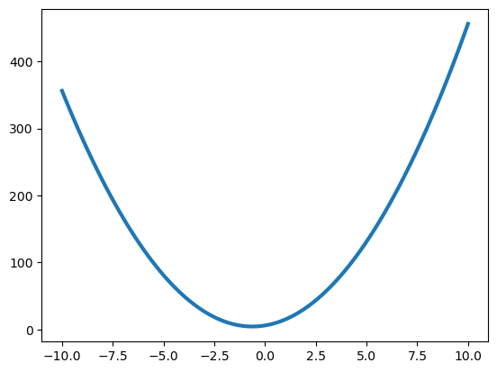

```python
import numpy as np               # for creating range
import matplotlib.pyplot as plt  # for ploting

x= np.linspace(start=-10,stop=10,num=100)

## 2nd order Polynolinal
poly2= np.poly1d([4,5,6])

## Output
y= poly2(x)

## Plot of y
plt.plot(x,y,lw=3)    # Plot y versus x as lines

plt.show()
```

### Example: Curve fitting by Polynomial

To fit the followibg data by a polynomial...

| Var | Value |
| --- | --- |
| x | 0, 10, 20, 30, 40, 50, 60, 70, 80, 90 |
| y | 76, 92, 106, 123, 132, 151, 179, 203, 227, 249 |

```python
##import packages...
import numpy as np
import numpy.polynomial.polynomial as poly
import matplotlib.pyplot as plt

x= np.array([0, 10, 20, 30, 40, 50, 60, 70, 80, 90])
y= np.array([76, 92, 106, 123, 132, 151, 179, 203, 227, 249])
```

```python
## coefficients...
coeffs= poly.polyfit(x,y,2)
coeffs
```

```
array([7.81909091e+01, 1.10204545e+00, 9.12878788e-03])
```

```python
## fitted values...
yfit= poly.polyval(x,coeffs)
yfit
```

```
array([ 78.19090909,  90.12424242, 103.88333333, 119.46818182,
       136.87878788, 156.11515152, 177.17727273, 200.06515152,
       224.77878788, 251.31818182])
```

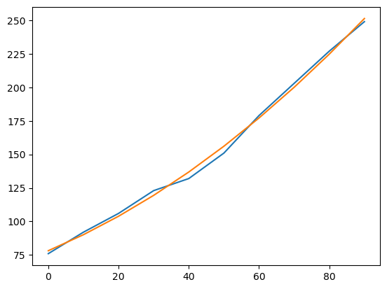

```python
## Plot...
plt.plot(x,y,x,yfit)
plt.show()
```

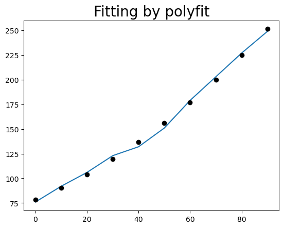

```python
plt.plot(x,y,x,yfit,'ko')
plt.title('Fitting by polyfit',size=20)
plt.show()
```

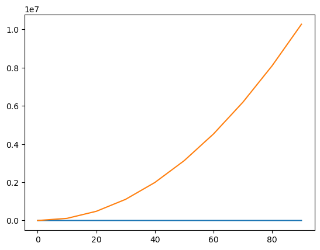

```python
x= np.array([0, 10, 20, 30, 40, 50, 60, 70, 80, 90])
y= np.array([76, 92, 106, 123, 132, 151, 179, 203, 227, 249])

## Creating a function
def fun(a,b,c,x):
    return a*x**2 + b*x + c

## Optimize the parameters
from scipy.optimize import curve_fit
par, var=curve_fit(fun,x,y)
a,b,c =par

## Plot
plt.plot(x,y,x,fun(a,b,c,x))
plt.show()
```